# Air Quality Interpolation

Saad Saif

12/7/2019

## Getting Nearby Stations

```r
library(sf)
radius = 150000 # Define radius to get stations in
pointLngLat = c(7.6, 52) # Define Longitude and Latitude of the desired point
stations = read.csv("data/AirBase_v8_stations.csv", sep = "\t", stringsAsFactors = FALSE)
stations.sf = st_as_sf(stations, coords = c("station_longitude_deg", "station_latitude_deg"), crs = 4326)
point.sfc = st_sfc(st_point(pointLngLat), crs = 4326) # Center point with 4326 EPSG
distances = st_distance(stations.sf, point.sfc) # All distances from the stations
sel = as.numeric(distances) < radius
stationsInRadius = stations.sf[sel,]
stationsInRadius
## Simple feature collection with 391 features and 18 fields
## geometry type:  POINT
## dimension:      XY
## bbox:           xmin: 5.61915 ymin: 50.69944 xmax: 9.712341 ymax: 53.21238
## epsg (SRID):    4326
## proj4string:    +proj=longlat +datum=WGS84 +no_defs
## First 10 features:
##      station_european_code station_local_code country_iso_code
## 1004               DENW025            DENW025               DE
## 1026               DENW009            DENW009               DE
## 1102               DEHE046            DEHE046               DE
## 1111               DENW323            DENW323               DE
## 1112               DENW322            DENW322               DE
## 1122               DEUB007            DEUB007               DE
## 1133               DENW003            DENW003               DE
## 1143               DENW200            DENW200               DE
## 1144               DENW146            DENW146               DE
## 1145               DENW140            DENW140               DE
##      country_name                 station_name station_start_date
## 1004      Germany                    Altendorf         1981-08-01
## 1026      Germany                       Asseln         1980-12-01
## 1102      Germany                  Bad Arolsen         1999-05-11
## 1111      Germany  Bad Salzuflen Bahnhofstraße         2012-01-24
## 1112      Germany     Bad Salzuflen Beetstraße         2012-01-24
## 1122      Germany                       Bassum         1980-01-01
## 1133      Germany                    Bergkamen         1986-11-01
## 1143      Germany   Bielefeld Detmolder Straße         2006-12-28
## 1144      Germany Bielefeld Detmolder Straße 9         2005-04-29
## 1145      Germany Bielefeld Osnabrücker Straße         2005-01-01
##      station_end_date type_of_station station_ozone_classification
## 1004       1996-12-31      Background
## 1026       1996-12-31      Background                     suburban
## 1102                       Background                        rural
## 1111                          Traffic                        urban
## 1112                          Traffic                        urban
## 1122       2004-12-12      Background                        rural
## 1133       1996-11-25      Background
## 1143       2008-01-10         Traffic
## 1144       2006-12-21         Traffic
## 1145       2006-01-03         Traffic
##      station_type_of_area station_subcat_rural_back street_type
## 1004                urban                   unknown     Unknown
## 1026             suburban                   unknown     Unknown
## 1102                rural                   unknown
## 1111                urban                   unknown
## 1112                urban                   unknown
## 1122                rural                   unknown
## 1133             suburban                   unknown
## 1143                urban                   unknown
## 1144                urban                   unknown
## 1145                urban                   unknown
##      station_altitude          station_city lau_level1_code
## 1004               70                 ESSEN
## 1026               85              DORTMUND
## 1102              343 BAD AROLSEN/KOHLGRUND
## 1111               76
## 1112               97
## 1122               52                BASSUM
## 1133               72             BERGKAMEN
## 1143              137
## 1144              137
## 1145              135
##      lau_level2_code    lau_level2_name EMEP_station
## 1004         5113000       Essen, Stadt           no
## 1026                                              no
## 1102         6635002 Bad Arolsen, Stadt           no
## 1111                                              no
## 1112                                              no
## 1122                                             yes
## 1133         5978004   Bergkamen, Stadt           no
## 1143         5711000   Bielefeld, Stadt           no
## 1144         5711000   Bielefeld, Stadt           no
## 1145         5711000   Bielefeld, Stadt           no
##                       geometry
## 1004 POINT (6.966269 51.45851)
## 1026 POINT (7.592664 51.52418)
## 1102  POINT (8.928172 51.4309)
## 1111 POINT (8.744697 52.08096)
## 1112  POINT (8.756275 52.0838)
## 1122  POINT (8.70038 52.85075)
## 1133  POINT (7.65168 51.62374)
## 1143 POINT (8.552803 52.00562)
## 1144 POINT (8.533103 52.01496)
## 1145 POINT (8.490933 52.00047)
```

## Downlaoding Time Series Dataset

The following script fetches and stores all air quality time series `.csv` files from the stations that exist in the specified radius of the provided point. It does so by using `https://fme.discomap.eea.europa.eu/fmedatastreaming/AirQualityDownload/AQData_Extract.fmw` link from European Environmental Agency (EEA) and dynamically adding the appropriate query pramaters in the base URL. The code is now synchronous and could tak longer if the specified radius is too big or the data is large but an asynchronous loop can be used to overcome this challenge using `doParallel` R package.

Define if data needs to be downloaded

```r
downloadData = F
```

```r
if (downloadData){

library(urltools)
library(httr)

# TODO: make loops parallel
# library(doParallel)

requestTimeoutInSec = 5
pollutantCode = 8 # 8 is the pollutant code for NO2
fromYear = 2017
tillYear = 2017
source = "E1a"
restrictCountryDataTo = "DE"

#stationsInRadius = stations[ stations$country_iso_code == "DE", ]

for (i in c(1:(length(stationsInRadius[[1]])))){
  print(paste0("In iteration", i))
  countryCode = stationsInRadius[i,]$country_iso_code
  cityName = stationsInRadius[i,]$station_city

  if (is.na(countryCode) || countryCode == "" || is.na(cityName) || cityName == ""){
    print("City or country was not found, skipping..")
    next
  }
  if (restrictCountryDataTo != ""){
    countryCode = restrictCountryDataTo
  }
  result = NA
  getOperation = try({

    request = GET("https://fme.discomap.eea.europa.eu/fmedatastreaming/AirQualityDownload/AQData_Extract.fmw",
              query = list(CountryCode = countryCode,
                           CityName = cityName,
                           Pollutant=pollutantCode,
                           Year_from=fromYear,
                           Year_to=tillYear,
                           Source=source,
                           Output="TEXT"),
              timeout(requestTimeoutInSec),
              verbose())

    if (status_code(request) != 200){
      print("Request failed")
      stop("Error")
    }

    result = httr::content(request, encoding = "UTF-8")
  })

  if (inherits(getOperation, "try-error")){
    print(paste0("For city ", cityName))
    print("Status code was not 200, skipping..")
    next
  }

  library(XML)
  parsed = xmlToList(xmlParse(result)) # Parse HTML document
  links = parsed$body$p;
  links = strsplit(links, split = "\n");

  for (i in c(1:length(links[[1]]))){
    link = links[[1]][i]
    print(paste0("Link is", link));
    data = NA
    getOperation = try({
      linkPath = url_parse(link)$path
      fileName = tail(strsplit(linkPath, "/")[[1]], n=1)
      download.file(link, destfile = fileName)
      print(paste0("For city ", cityName))
      print(paste0("Wrote file named ", fileName))
    })

    if (inherits(getOperation, "try-error")){
      print(paste0("For city ", cityName))
      print("File was not downloaded, skipping..")
      next
    }
  }
}
}
```

## Pre-processing the Dataset

Read Files

```r
files = list.files("data", pattern = "DE_5*", full.names = TRUE)
data = lapply(files, function(x)read.csv(x, fileEncoding = "UTF-16", header = TRUE, sep = ","))
print(paste0("Number of files read: ", length(files)))
```

```
## [1] "Number of files read: 117"
```

Convert DatetimeBegin to POSIXct timr from factor

```r
Sys.setenv(TZ = "UTC") # make sure times are not interpreted as DST
data = lapply(data, function(f) {
        f$t = as.POSIXct(f$DatetimeBegin)
        f[order(f$t), ]
    })
```

Deselect smaller datasets that do not contain hourly data

```r
data = data[sapply(data, nrow) > 1000]
names(data) =  sapply(data, function(f) unique(f$AirQualityStationEoICode))
length(data) == length(unique(names(data)))
```

```
## [1] TRUE
```

Combine all files using `xts::cbind`, so that they are matched based on time

```r
library(xts)
data = lapply(data, function(f) xts(f$Concentration, f$t))
aq = do.call(cbind, data)
```

Remove stations with more than 75% missing values:

```r
sel = apply(aq, 2, function(x) sum(is.na(x)) < 0.75 * 365 * 24)
aqsel = aq[, sel] # stations are in columns
```

Filter urban stations

```r
library(tidyverse)
read.csv("data/AirBase_v8_stations.csv", sep = "\t", stringsAsFactors = FALSE) %>%
  as_tibble %>%
  filter(station_type_of_area == "urban", type_of_station == "Background") -> backgroundAndUrban

library(stars)
backgroundAndUrban.sf = st_as_sf(backgroundAndUrban, coords = c("station_longitude_deg", "station_latitude_deg"), crs = 4326)
```

Filter our selected stations as well

```r
sel =  colnames(aqsel) %in% backgroundAndUrban$station_european_code
aqsel = aqsel[,sel]

if (is.null(colnames(aqsel))){
  stop("No stations match urban and background stations in the processed stations list")
}
```

Compute station means and show them on a map

```r
tb = tibble(NO2 = apply(aqsel, 2, mean, na.rm = TRUE), station_european_code = colnames(aqsel))
crs = 32632
right_join(backgroundAndUrban.sf, tb) %>% st_transform(crs) -> no2.sf
## Joining, by = "station_european_code"

# load German boundaries
data(air, package = "spacetime")
de <- st_transform(st_as_sf(DE_NUTS1), crs)
```

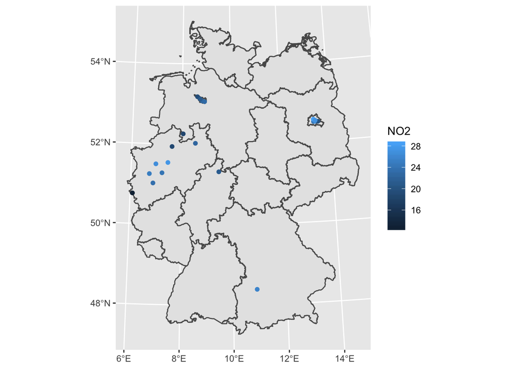

```r
ggplot() + geom_sf(data = de) +  geom_sf(data = no2.sf, mapping = aes(col = NO2))
```

## Sample Variogram

To identify a model for the mean and for the spatial correlations. Here we use the `variogram` method from the `gstat` package. The formula `NO2~1` is used to select the variable of interest from the data file (NO2), and to specify the mean model: `~1` refers to an intercept-only (unknown, constant mean) model.

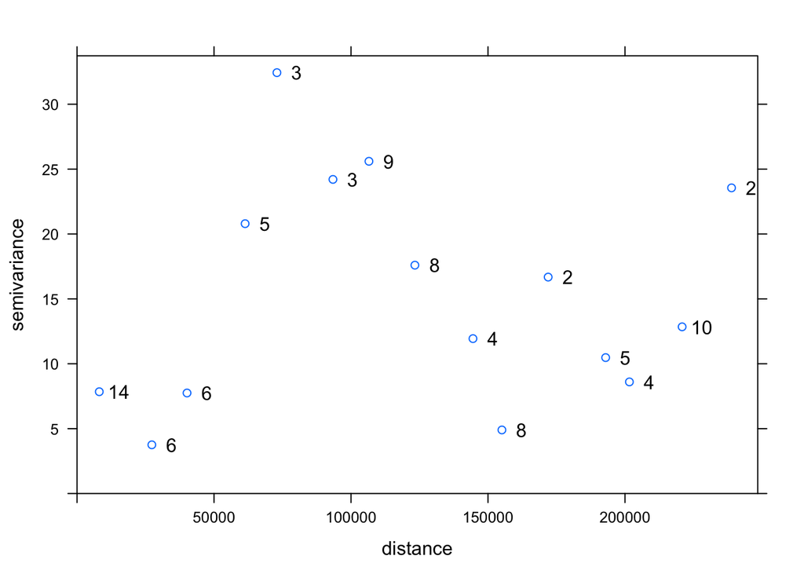

```r
# Sample Variogram

library(gstat)
v = variogram(NO2~1, no2.sf)
plot(v, plot.numbers = TRUE)
```

This chooses default maximum distance (`cutoff`: one third of the length of the bounding box diagonal) and (constant) interval widths (`width`: cutoff divided by 15). These defaults can be changed, e.g. by

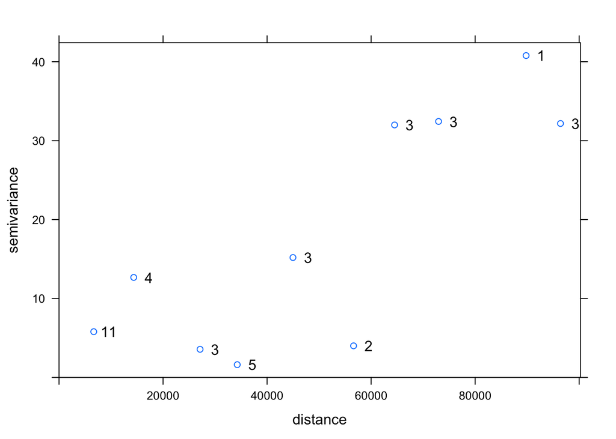

```r
# With custom cutoffs
v0 = variogram(NO2~1, no2.sf, cutoff = 100000, width = 10000)
plot(v0, plot.numbers = TRUE)
```

### Fitting Variogram Models

In order to progress toward spatial predictions, we need a variogram model for (potentially) all distances rather than the set of estimates derived above. We can fit a model to estimate all distance values. Feel free to change `vgm` parameters. Here we used 30000 becuase that best fits the data in our case.

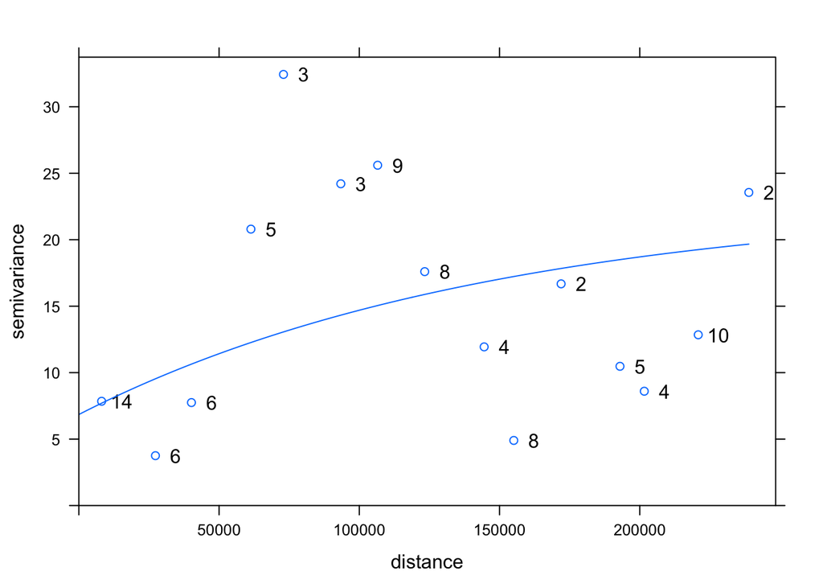

```r
v.m = fit.variogram(v, vgm(1, "Exp", 30000, 1))
plot(v, v.m, plot.numbers = TRUE)
```

## Kirging Interpolation

Kriging involves the prediction of a phenomenon at arbitrary locations. Typically, when we interpolate a variable, we do that on points on a regular grid covering the target area. We first create a stars object with a raster covering the target area, and NA’s outside it:

```r
# build a grid over Germany:
st_bbox(de) %>%
  st_as_stars(dx = 10000) %>%
  st_set_crs(crs) %>%
  st_crop(de) -> grd
grd
## stars object with 2 dimensions and 1 attribute
## attribute(s):
##     values
##  Min.   :0
##  1st Qu.:0
##  Median :0
##  Mean   :0
##  3rd Qu.:0
##  Max.   :0
##  NA's   :2076
## dimension(s):
##   from to  offset  delta                       refsys point values
## x    1 65  280741  10000 +proj=utm +zone=32 +datum...    NA   NULL [x]
## y    1 87 6101239 -10000 +proj=utm +zone=32 +datum...    NA   NULL [y]

k = krige(NO2~1, no2.sf, grd, v.m)
## [using ordinary kriging]
```

```
#> [using ordinary kriging]
```

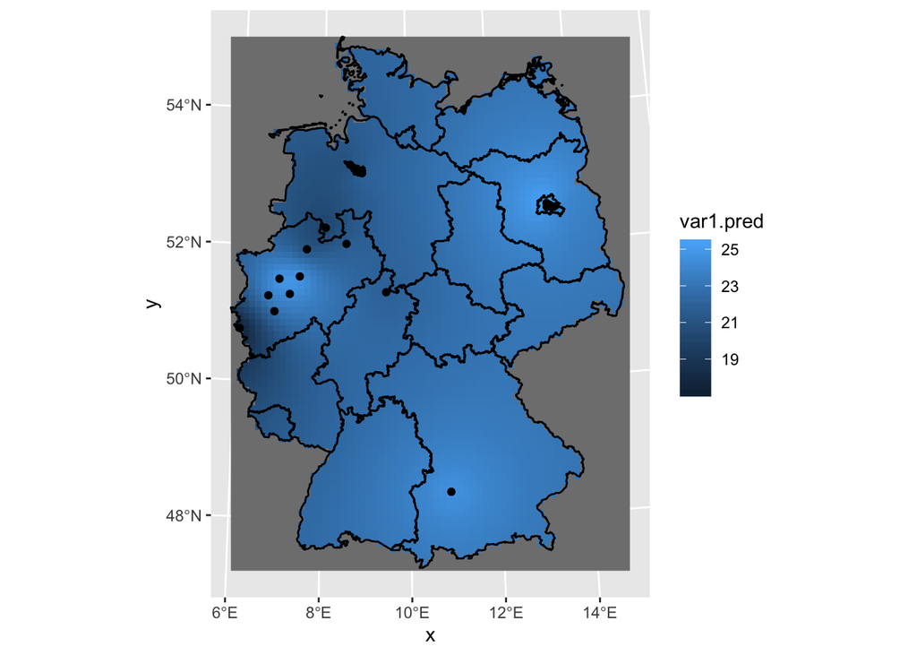

```r
ggplot() + geom_stars(data = k, aes(fill = var1.pred, x = x, y = y)) +
    geom_sf(data = st_cast(de, "MULTILINESTRING")) +
    geom_sf(data = no2.sf)
```